# aula 04 :: PostgreSQL + R

Ricardo Rodrigues da Silveira Filho

17 abr 2021

### 0) Setup

- Carregando os pacotes a serem utilizados na sessão

```r
library(connections)
library(DBI)
library(RPostgres)
library(tidyverse)
```

- Ps.: Optei por mostrar o *head* dos *chunks* quando a linguagem utilizada foi o *SQL*.

### 1) PostgreSQL

- Informações necessárias para lidar com o postgreSQL:
  - ip
  - Porta (por default: 5432)
  - dbname
  - user
  - pw
  - driver
- Instruções básicas pgAdmin
- Biblioteca `connections`
  - Possibilidade de visualização “point-and-click” do *cluster* via `RStudio`

```r
conn <- connection_open(RPostgres::Postgres(),
                        host = "localhost",
                        user = Sys.getenv("DBUSER"),
                        dbname = "teste01",
                        password = Sys.getenv("DBPASSWORD"))
```

- Possibilidade de criar um arquivo *.sql, para rodar via `RStudio`
  - Ver `SQL Script` no menu `File` > `New File`

````
```{r, connection = conn, engine="sql"}
````

```sql
-- !preview conn=conn

-- SELECT * from informacoes limit 10

-- ou

-- SELECT incidente, assunto1
-- FROM informacoes

-- ou

SELECT incidente, informacoes.assunto1 assunto, detalhes.classe
FROM informacoes
INNER JOIN detalhes using (incidente)
LIMIT 6
```

6 records

| incidente | assunto | classe |
| --- | --- | --- |
| 2635061 | DIREITO PROCESSUAL CIVIL E DO TRABALHO \| Processo e Procedimento | AI |
| 2635062 | DIREITO ADMINISTRATIVO E OUTRAS MATÉRIAS DE DIREITO PÚBLICO \| Serviços \| Saúde \| Tratamento Médico-Hospitalar e/ou Fornecimento de Medicamentos | AI |
| 2635063 | DIREITO PENAL \| Parte Geral \| Tipicidade \| Princípio da Insignificância | AI |
| 2635064 | DIREITO PROCESSUAL PENAL \| Ação Penal \| Nulidade | HC |
| 2635065 | DIREITO ADMINISTRATIVO E OUTRAS MATÉRIAS DE DIREITO PÚBLICO \| Intervenção no Domínio Econômico \| Expurgos Inflacionários / Planos Econômicos | MS |
| 2635066 | DIREITO ADMINISTRATIVO E OUTRAS MATÉRIAS DE DIREITO PÚBLICO \| Servidor Público Civil \| Pensão | MS |

````
```
````

- Fazendo *queries* com o `dplyr`
  - Exemplo 1

```r
dplyr::tbl(conn, "informacoes") %>%
    select(incidente, assunto = assunto1) %>%
    collect() %>%
    head()
```

```
## # A tibble: 6 x 2
##   incidente assunto
##   <chr>     <chr>
## 1 2635061   "DIREITO PROCESSUAL CIVIL E DO TRABALHO | Processo e Procedimento "
## 2 2635062   "DIREITO ADMINISTRATIVO E OUTRAS MATÉRIAS DE DIREITO PÚBLICO | Serv…
## 3 2635063   "DIREITO PENAL | Parte Geral | Tipicidade | Princípio da Insignific…
## 4 2635064   "DIREITO PROCESSUAL PENAL | Ação Penal | Nulidade "
## 5 2635065   "DIREITO ADMINISTRATIVO E OUTRAS MATÉRIAS DE DIREITO PÚBLICO | Inte…
## 6 2635066   "DIREITO ADMINISTRATIVO E OUTRAS MATÉRIAS DE DIREITO PÚBLICO | Serv…
```

```
- Exemplo 2
```

```r
selecionar <- function(conn = NULL, tbl, ...) {
    dplyr::tbl(conn, tbl) %>%
        dplyr::select(...) %>%
        dplyr::collect()
}

selecionar(conn = conn, "detalhes", incidente, sigilo, meio) %>%
    head()
```

```
## # A tibble: 6 x 3
##   incidente sigilo  meio
##   <chr>     <chr>   <chr>
## 1 2635061   Público Processo Físico
## 2 2635062   Público Processo Físico
## 3 2635063   Público Processo Físico
## 4 2635064   Público Processo Físico
## 5 2635065   Público Processo Físico
## 6 2635066   Público Processo Físico
```

```r
selecionar(conn = conn, "detalhes", 1, 2) %>%
    head()
```

```
## # A tibble: 6 x 2
##   incidente meio
##   <chr>     <chr>
## 1 2635061   Processo Físico
## 2 2635062   Processo Físico
## 3 2635063   Processo Físico
## 4 2635064   Processo Físico
## 5 2635065   Processo Físico
## 6 2635066   Processo Físico
```

- Fazendo *queries* com o `DBI`

```r
DBI::dbGetQuery(conn, "
                select incidente, assunto1 as assunto
                from informacoes
                limit 6")
```

```
##   incidente
## 1   2635061
## 2   2635062
## 3   2635063
## 4   2635064
## 5   2635065
## 6   2635066
##                                                                                                                                            assunto
## 1                                                                                DIREITO PROCESSUAL CIVIL E DO TRABALHO | Processo e Procedimento
## 2 DIREITO ADMINISTRATIVO E OUTRAS MATÉRIAS DE DIREITO PÚBLICO | Serviços | Saúde | Tratamento Médico-Hospitalar e/ou Fornecimento de Medicamentos
## 3                                                                         DIREITO PENAL | Parte Geral | Tipicidade | Princípio da Insignificância
## 4                                                                                                DIREITO PROCESSUAL PENAL | Ação Penal | Nulidade
## 5    DIREITO ADMINISTRATIVO E OUTRAS MATÉRIAS DE DIREITO PÚBLICO | Intervenção no Domínio Econômico | Expurgos Inflacionários / Planos Econômicos
## 6                                                   DIREITO ADMINISTRATIVO E OUTRAS MATÉRIAS DE DIREITO PÚBLICO | Servidor Público Civil | Pensão
```

- Linguagem SQL
  - "" somente para objetos
  - ’’ para identificadores
    - ex.:

````
```{r, connection = conn, wrapper = TRUE, engine="sql"}
````

```sql
SELECT *
FROM "detalhes"
WHERE classe = 'AI'
OR relator_atual = 'MINISTRO PRESIDENTE'
LIMIT 6
```

6 records

| incidente | meio | sigilo | numero_unico | classe | numero | relator_atual | detalhes_id |
| --- | --- | --- | --- | --- | --- | --- | --- |
| 2635061 | Processo Físico | Público | NA | AI | 725002 | MIN. CÁRMEN LÚCIA | 1 |
| 2635062 | Processo Físico | Público | NA | AI | 725006 | MIN. CELSO DE MELLO | 2 |
| 2635063 | Processo Físico | Público | NA | AI | 725007 | MIN. MENEZES DIREITO | 3 |
| 2635067 | Processo Físico | Público | NA | AI | 725005 | MIN. CELSO DE MELLO | 7 |
| 2635068 | Processo Físico | Público | NA | AI | 725011 | MIN. AYRES BRITTO | 8 |
| 2635069 | Processo Físico | Público | NA | AI | 725013 | MIN. AYRES BRITTO | 9 |

````
```
````

```
    - ou...
```

```r
DBI::dbGetQuery(conn, "
                SELECT *
                FROM detalhes
                WHERE classe = 'AI'
                OR relator_atual = 'MINISTRO PRESIDENTE'
                LIMIT 6")
```

```
##   incidente            meio  sigilo numero_unico classe numero
## 1   2635061 Processo Físico Público         <NA>     AI 725002
## 2   2635062 Processo Físico Público         <NA>     AI 725006
## 3   2635063 Processo Físico Público         <NA>     AI 725007
## 4   2635067 Processo Físico Público         <NA>     AI 725005
## 5   2635068 Processo Físico Público         <NA>     AI 725011
## 6   2635069 Processo Físico Público         <NA>     AI 725013
##          relator_atual detalhes_id
## 1    MIN. CÁRMEN LÚCIA           1
## 2  MIN. CELSO DE MELLO           2
## 3 MIN. MENEZES DIREITO           3
## 4  MIN. CELSO DE MELLO           7
## 5    MIN. AYRES BRITTO           8
## 6    MIN. AYRES BRITTO           9
```

```
    - ou...
```

```r
dplyr::tbl(conn, "detalhes") %>%
    filter(classe == "AI" | relator_atual == "MINISTRO PRESIDENTE") %>%
    head()
```

```
## # Source:   lazy query [?? x 8]
## # Database: postgres [ricardo@localhost:5432/teste01]
##   incidente meio    sigilo numero_unico classe numero relator_atual  detalhes_id
##   <chr>     <chr>   <chr>  <chr>        <chr>  <chr>  <chr>                <int>
## 1 2635061   Proces… Públi… <NA>         AI     725002 MIN. CÁRMEN L…           1
## 2 2635062   Proces… Públi… <NA>         AI     725006 MIN. CELSO DE…           2
## 3 2635063   Proces… Públi… <NA>         AI     725007 MIN. MENEZES …           3
## 4 2635067   Proces… Públi… <NA>         AI     725005 MIN. CELSO DE…           7
## 5 2635068   Proces… Públi… <NA>         AI     725011 MIN. AYRES BR…           8
## 6 2635069   Proces… Públi… <NA>         AI     725013 MIN. AYRES BR…           9
```

- Demonstrar *query* realizada com o `dplyr`

```r
df <- dplyr::tbl(conn, "detalhes") %>%
    filter(classe == "AI" | relator_atual == "MINISTRO PRESIDENTE") %>%
    head()

dplyr::show_query(df)
```

```
## <SQL>
## SELECT *
## FROM "detalhes"
## WHERE ("classe" = 'AI' OR "relator_atual" = 'MINISTRO PRESIDENTE')
## LIMIT 6
```

- Enviando um *query* para “pedir” o banco de dados posteriormente
  - Útil para métodos de paginação (para `shiny`, por exemplo)

```r
df2 <- dbSendQuery(conn, "
            SELECT *
            FROM detalhes
            WHERE classe = 'AI'
            OR relator_atual = 'MINISTRO PRESIDENTE'
            ")

# O argumento "n" limita o número de eventos a serem mostrados
df2_fetch <- dbFetch(df2, n = 6)

df2_fetch
```

```
##   incidente            meio  sigilo numero_unico classe numero
## 1   2635061 Processo Físico Público         <NA>     AI 725002
## 2   2635062 Processo Físico Público         <NA>     AI 725006
## 3   2635063 Processo Físico Público         <NA>     AI 725007
## 4   2635067 Processo Físico Público         <NA>     AI 725005
## 5   2635068 Processo Físico Público         <NA>     AI 725011
## 6   2635069 Processo Físico Público         <NA>     AI 725013
##          relator_atual detalhes_id
## 1    MIN. CÁRMEN LÚCIA           1
## 2  MIN. CELSO DE MELLO           2
## 3 MIN. MENEZES DIREITO           3
## 4  MIN. CELSO DE MELLO           7
## 5    MIN. AYRES BRITTO           8
## 6    MIN. AYRES BRITTO           9
```

### Criando tabelas a partir de outras

- Tutorial: https://rpg.consudata.com.br/posts/2021-01-03-tidypg-cheatsheet-criando-tabelas-a-partir-de-outras-parte-1/
- Banco de dados a ser utilizado:

```r
df3 <- dplyr::tbl(conn, "detalhes") %>%
    filter(classe == "AI" | relator_atual == "MINISTRO PRESIDENTE")
```

- Utilizando `tidyverse`

```r
df3 %>%
    head(n = 2)
```

```
## # Source:   lazy query [?? x 8]
## # Database: postgres [ricardo@localhost:5432/teste01]
##   incidente meio    sigilo numero_unico classe numero relator_atual  detalhes_id
##   <chr>     <chr>   <chr>  <chr>        <chr>  <chr>  <chr>                <int>
## 1 2635061   Proces… Públi… <NA>         AI     725002 MIN. CÁRMEN L…           1
## 2 2635062   Proces… Públi… <NA>         AI     725006 MIN. CELSO DE…           2
```

- Utilizando `DBI`

```r
DBI::dbGetQuery(conn, "
                SELECT *
                FROM detalhes
                ORDER BY incidente
                LIMIT 2
                ")
```

```
##   incidente            meio  sigilo numero_unico classe numero
## 1   2635061 Processo Físico Público         <NA>     AI 725002
## 2   2635062 Processo Físico Público         <NA>     AI 725006
##         relator_atual detalhes_id
## 1   MIN. CÁRMEN LÚCIA           1
## 2 MIN. CELSO DE MELLO           2
```

- Para garantir que uma tabela tenha “ordem”
  - Criando uma variável de identificação (ID)

```r
dbExecute(conn, "
          ALTER TABLE detalhes ADD COLUMN detalhes_id SERIAL
          ")
```

```r
dbGetQuery(conn, "
           SELECT *
           FROM detalhes
           ORDER BY detalhes_id
           LIMIT 2
           ")
```

```
##   incidente            meio  sigilo numero_unico classe numero
## 1   2635061 Processo Físico Público         <NA>     AI 725002
## 2   2635062 Processo Físico Público         <NA>     AI 725006
##         relator_atual detalhes_id
## 1   MIN. CÁRMEN LÚCIA           1
## 2 MIN. CELSO DE MELLO           2
```

- Filtrando observações

```r
dbGetQuery(conn, "
           SELECT *
           FROM detalhes
           WHERE relator_atual != 'MINISTRO PRESIDENTE'
           LIMIT 6")
```

```
##   incidente            meio  sigilo              numero_unico classe numero
## 1   2635061 Processo Físico Público                      <NA>     AI 725002
## 2   2635062 Processo Físico Público                      <NA>     AI 725006
## 3   2635063 Processo Físico Público                      <NA>     AI 725007
## 4   2635064 Processo Físico Público 0004754-72.2008.0.01.0000     HC  95900
## 5   2635065 Processo Físico Público 0004755-57.2008.0.01.0000     MS  27520
## 6   2635066 Processo Físico Público 0004756-42.2008.0.01.0000     MS  27524
##          relator_atual detalhes_id
## 1    MIN. CÁRMEN LÚCIA           1
## 2  MIN. CELSO DE MELLO           2
## 3 MIN. MENEZES DIREITO           3
## 4    MIN. ELLEN GRACIE           4
## 5  MIN. CELSO DE MELLO           5
## 6       MIN. EROS GRAU           6
```

```r
# Para "diferente", <> pode ser utilizado
# Para comparação "==", usar somente "="
```

```r
df3 %>%
    filter(relator_atual == "MINISTRO PRESIDENTE") %>%
    head()
```

```
## # Source:   lazy query [?? x 8]
## # Database: postgres [ricardo@localhost:5432/teste01]
##   incidente meio    sigilo numero_unico classe numero relator_atual  detalhes_id
##   <chr>     <chr>   <chr>  <chr>        <chr>  <chr>  <chr>                <int>
## 1 2635078   Proces… Públi… <NA>         AI     725080 MINISTRO PRES…          18
## 2 2635086   Proces… Públi… <NA>         AI     725079 MINISTRO PRES…          26
## 3 2635088   Proces… Públi… <NA>         AI     725087 MINISTRO PRES…          28
## 4 2635090   Proces… Públi… <NA>         AI     725100 MINISTRO PRES…          30
## 5 2635140   Proces… Públi… <NA>         AI     725073 MINISTRO PRES…          80
## 6 2635141   Proces… Públi… <NA>         AI     725075 MINISTRO PRES…          81
```

- Adicionar uma tabela

```r
new_data <- dbFetch(df2, n = 20)

dbWriteTable(conn, "nova_tabela", new_data)
```

```
- ou...
    - Unindo linhas (*bind_rows*)
```

```r
dbExecute(conn, "
          CREATE TABLE df AS
          (
          SELECT * FROM detalhes
          UNION
          SELECT * FROM nova_tabela
          )
          ")
```

```
## [1] 101
```

```r
# UNION ALL: Mantém as duplicatas
# UNION: Não adiciona duplicatas
```

```
- Resultado `CREATE TABLE`:
```

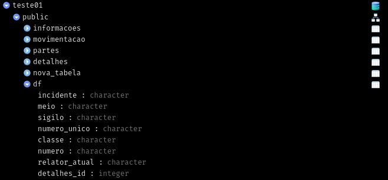

- Apagando uma tabela

```r
dbExecute(conn, "DROP TABLE df")
```

```
## [1] 0
```

```
- Resultado `DROP TABLE`
```

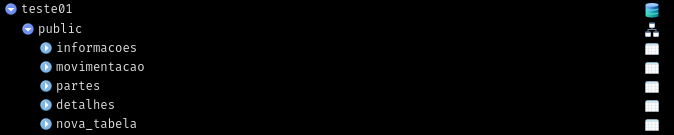

- Unindo `data.frames` horizontalmente

```r
data01 <- data.frame(a = 1:5,
                     b = letters[1:5])

data02 <- data.frame(c = c(6:10),
                     d = letters[6:10])

data0102 <- bind_cols(data01, data02)
```

- Com `DBI`

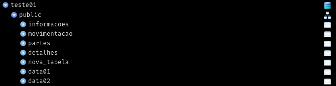

```r
dbWriteTable(conn, "data01", data01, append = TRUE)
dbWriteTable(conn, "data02", data02, append = TRUE)
```

- Unindo `data.frames` horizontalmente com `SQL`

```r
# Adicionar ID (SERIAL)
dbExecute(conn, "ALTER TABLE data01 ADD COLUMN id_1 SERIAL")
dbExecute(conn, "ALTER TABLE data02 ADD COLUMN id_2 SERIAL")

dbExecute(conn, "
          CREATE TABLE data0102 as
          (SELECT * FROM data01, data02
          WHERE data01.id_1 = data02.id_2)
          ")
```

### Joins no R e no PostgreSQL (“Empilhamento”)

#### R

- Tutorial:
  - https://rpg.consudata.com.br/posts/2021-01-03-joins-no-r-e-no-postgresql/
- Perguntas antes de fazer um `join`
  1. Quero preservar todas as linhas das duas tabelas?
  2. Quero preservar todas as linhas de apenas uma tabela?
  3. Quero preservar todas as colunas de ambas tabelas?
  4. Quero preservar *NA*s (no **R**) ou *NULL*s no **PostgreSQL**?
  5. Quero juntar as tabelas com base na comparação de apenas um par de colunas, ou seja, coluna *a* da *tbl1* com coluna *b* da *tbl2*?
  6. Se fizer conforme a pergunta 5, o que vai acontecer com colunas com o mesmo nome nas duas tabelas, mas que não pretendo comparar para efeitos de junção?
  7. Quero valores das duas tabelas ou apenas de uma?
- Criando `data.frames`

```r
set.seed(35)
d01 <- tibble::tibble(a = sample(1:5, 5),
                      b = sample(c(NA_real_, 6:9), 5),
                      c = sample(c(NA_character_, sample(letters, 4)), 5))
knitr::kable(d01)
```

| a | b | c |
| --- | --- | --- |
| 2 | NA | j |
| 5 | 6 | i |
| 1 | 9 | NA |
| 3 | 8 | u |
| 4 | 7 | q |

```r
set.seed(936)
d02 <- tibble::tibble(a = sample(c(NA_real_, 2:7), 7),
                      b = sample(c(NA_real_, 3:8), 7))
knitr::kable(d02)
```

| a | b |
| --- | --- |
| 4 | 5 |
| 2 | 3 |
| 7 | 6 |
| 6 | 8 |
| 3 | NA |
| 5 | 7 |
| NA | 4 |

- Realizando um `inner_join`

```r
d03 <- inner_join(d01, d02, by = "a")

knitr::kable(d03)
```

| a | b.x | c | b.y |
| --- | --- | --- | --- |
| 2 | NA | j | 3 |
| 5 | 6 | i | 7 |
| 3 | 8 | u | NA |
| 4 | 7 | q | 5 |

- “Coalescendo”

```r
d03 %>%
    mutate(b = coalesce(b.x, b.y),
           b.x = NULL,
           b.y = NULL)
```

```
## # A tibble: 4 x 3
##       a c         b
##   <dbl> <chr> <dbl>
## 1     2 j         3
## 2     5 i         6
## 3     3 u         8
## 4     4 q         7
```

- Realizar `inner_join` com mais de uma variável

```r
knitr::kable(inner_join(d01, d02, by = c("a", "b")))
```

| a | b | c |
| --- | --- | --- |

- `left_join` e `right_join`
  - `left_join` preserva todas as linhas do `data.frame` à esquerda
  - `right_join` preserva todas as linhas do `data.frame` à direita

```r
knitr::kable(left_join(d01, d02, by = "a"))
```

| a | b.x | c | b.y |
| --- | --- | --- | --- |
| 2 | NA | j | 3 |
| 5 | 6 | i | 7 |
| 1 | 9 | NA | NA |
| 3 | 8 | u | NA |
| 4 | 7 | q | 5 |

```r
knitr::kable(right_join(d01, d02, by = "a"))
```

| a | b.x | c | b.y |
| --- | --- | --- | --- |
| 2 | NA | j | 3 |
| 5 | 6 | i | 7 |
| 3 | 8 | u | NA |
| 4 | 7 | q | 5 |
| 7 | NA | NA | 6 |
| 6 | NA | NA | 8 |
| NA | NA | NA | 4 |

- `full_join`
  - Unir os dois `data.frames` por completo

```r
knitr::kable(full_join(d01, d02, by = "a"))
```

| a | b.x | c | b.y |
| --- | --- | --- | --- |
| 2 | NA | j | 3 |
| 5 | 6 | i | 7 |
| 1 | 9 | NA | NA |
| 3 | 8 | u | NA |
| 4 | 7 | q | 5 |
| 7 | NA | NA | 6 |
| 6 | NA | NA | 8 |
| NA | NA | NA | 4 |

- `semi_join`
  - Pega somente os valores que correspondem ao índice dado

```r
knitr::kable(semi_join(d01, d02, by = "a"))
```

| a | b | c |
| --- | --- | --- |
| 2 | NA | j |
| 5 | 6 | i |
| 3 | 8 | u |
| 4 | 7 | q |

- `anti_join`
  - Operação inversa do `semi_join`

```r
knitr::kable(anti_join(d01, d02, by = "a"))
```

| a | b | c |
| --- | --- | --- |
| 1 | 9 | NA |

#### PostgreSQL

- Adicionar dados no Postgre

```r
iwalk(list(d01 = d01, d02 = d02), ~ {
    dbWriteTable(conn, .y, .x)
})
```

- `INNER JOIN`
  - Uma chave apenas

```sql
SELECT * FROM d01 INNER JOIN d02 USING (a)
```

4 records

| a | b | c | b..4 |
| --- | --- | --- | --- |
| 2 | NA | j | 3 |
| 3 | 8 | u | NA |
| 4 | 7 | q | 5 |
| 5 | 6 | i | 7 |

```
- Mais de uma chave
```

```sql
SELECT * FROM d01 INNER JOIN d02 USING (a, b)
```

0 records

| a | b | c |
| --- | --- | --- |

- Exercícios PostgreSQL
  - https://pgexercises.com/